# Insurance_project

## converting the categorical variable into factors

```r
# Convert categorical variables to factors
insurance$sex <- as.factor(insurance$sex)
insurance$smoker <- as.factor(insurance$smoker)
insurance$region <- as.factor(insurance$region)
```

```r
head(insurance)
```

|  | age | sex | bmi | children | smoker | region | expenses | Age_Group |
| --- | --- | --- | --- | --- | --- | --- | --- | --- |
| 1 | 19 | female | 27.9 | 0 | yes | southwest | 16884.92 | 18-24 |
| 2 | 18 | male | 33.8 | 1 | no | southeast | 1725.55 | 18-24 |
| 3 | 28 | male | 33.0 | 3 | no | southeast | 4449.46 | 25-34 |
| 4 | 33 | male | 22.7 | 0 | no | northwest | 21984.47 | 25-34 |
| 5 | 32 | male | 28.9 | 0 | no | northwest | 3866.86 | 25-34 |
| 6 | 31 | female | 25.7 | 0 | no | southeast | 3756.62 | 25-34 |

```r
set.seed(42)  # For reproducibility
train_index <- createDataPartition(insurance$expenses, p = 0.8, list = FALSE)
train_data <- insurance[train_index, ]
test_data <- insurance[-train_index, ]
```

#Fiiting a regression model

```r
# Fit a linear regression model
lm_model <- lm(expenses ~ age + sex + bmi + children + smoker + region, data = train_data)

# Summary of the model
summary(lm_model)
```

```
##
## Call:
## lm(formula = expenses ~ age + sex + bmi + children + smoker +
##     region, data = train_data)
##
## Residuals:
##      Min       1Q   Median       3Q      Max
## -11055.8  -2819.6   -943.6   1517.9  25249.2
##
## Coefficients:
##                  Estimate Std. Error t value Pr(>|t|)
## (Intercept)     -12134.75    1082.63 -11.209  < 2e-16 ***
## age                257.13      13.20  19.473  < 2e-16 ***
## sexmale           -460.23     367.55  -1.252 0.210786
## bmi                342.62      31.77  10.785  < 2e-16 ***
## children           505.88     152.89   3.309 0.000969 ***
## smokeryes        23925.79     455.26  52.554  < 2e-16 ***
## regionnorthwest   -159.18     525.60  -0.303 0.762060
## regionsoutheast   -820.85     530.00  -1.549 0.121735
## regionsouthwest   -851.49     536.86  -1.586 0.113024
## ---
## Signif. codes:  0 '***' 0.001 '**' 0.01 '*' 0.05 '.' 0.1 ' ' 1
##
## Residual standard error: 5987 on 1063 degrees of freedom
## Multiple R-squared:  0.7583, Adjusted R-squared:  0.7565
## F-statistic: 416.8 on 8 and 1063 DF,  p-value: < 2.2e-16
```

```r
# Make predictions
predictions <- predict(lm_model, newdata = test_data)

# Evaluate the model
mse <- mean((test_data$expenses - predictions)^2)
rsq <- summary(lm_model)$r.squared
cat("Mean Squared Error:", mse, "\n")
```

```
## Mean Squared Error: 40566940
```

```r
cat("R^2 Score:", rsq, "\n")
```

```
## R^2 Score: 0.7582722
```

finding the p value and confidence interval

```r
# Get p-values from the summary
p_values <- summary(lm_model)$coefficients[, 4]

# Compute 95% confidence intervals
conf_intervals <- confint(lm_model, level = 0.95)

# Display p-values and confidence intervals
p_values
```

```
##     (Intercept)             age         sexmale             bmi        children
##    1.224155e-27    1.811564e-72    2.107863e-01    8.319583e-26    9.686265e-04
##       smokeryes regionnorthwest regionsoutheast regionsouthwest
##   7.920474e-298    7.620599e-01    1.217353e-01    1.130235e-01
```

```r
conf_intervals
```

```
##                       2.5 %      97.5 %
## (Intercept)     -14259.0844 -10010.4137
## age                231.2179    283.0367
## sexmale          -1181.4307    260.9721
## bmi                280.2856    404.9612
## children           205.8760    805.8900
## smokeryes        23032.4767  24819.1079
## regionnorthwest  -1190.5066    872.1472
## regionsoutheast  -1860.8197    219.1193
## regionsouthwest  -1904.9145    201.9343
```

##applying cross validation on the data and checking wherther the result is changingg or not

```r
set.seed(42)  # For reproducibility

# Define control for cross-validation
train_control <- trainControl(method = "cv", number = 10)  # 10-fold cross-validation

# Fit the linear regression model using cross-validation
lm_cv_model <- train(expenses ~ age + sex + bmi + children + smoker + region,
                     data = insurance,
                     method = "lm",
                     trControl = train_control)

# Display the results
print(lm_cv_model)
```

```
## Linear Regression
##
## 1338 samples
##    6 predictor
##
## No pre-processing
## Resampling: Cross-Validated (10 fold)
## Summary of sample sizes: 1205, 1204, 1204, 1204, 1203, 1205, ...
## Resampling results:
##
##   RMSE      Rsquared  MAE
##   6079.106  0.748536  4199.855
##
## Tuning parameter 'intercept' was held constant at a value of TRUE
```

```r
# Model results
lm_cv_results <- lm_cv_model$results
print(lm_cv_results)
```

```
##   intercept     RMSE Rsquared      MAE   RMSESD RsquaredSD    MAESD
## 1      TRUE 6079.106 0.748536 4199.855 431.7901  0.0511499 271.5206
```

```r
# Get the final model
final_model <- lm_cv_model$finalModel

# Check the summary of the final model
summary(final_model)
```

```
##
## Call:
## lm(formula = .outcome ~ ., data = dat)
##
## Residuals:
##      Min       1Q   Median       3Q      Max
## -11302.7  -2850.9   -979.6   1383.9  29981.7
##
## Coefficients:
##                 Estimate Std. Error t value Pr(>|t|)
## (Intercept)     -11941.6      987.8 -12.089  < 2e-16 ***
## age                256.8       11.9  21.586  < 2e-16 ***
## sexmale           -131.3      332.9  -0.395 0.693255
## bmi                339.3       28.6  11.864  < 2e-16 ***
## children           475.7      137.8   3.452 0.000574 ***
## smokeryes        23847.5      413.1  57.723  < 2e-16 ***
## regionnorthwest   -352.8      476.3  -0.741 0.458976
## regionsoutheast  -1035.6      478.7  -2.163 0.030685 *
## regionsouthwest   -959.3      477.9  -2.007 0.044921 *
## ---
## Signif. codes:  0 '***' 0.001 '**' 0.01 '*' 0.05 '.' 0.1 ' ' 1
##
## Residual standard error: 6062 on 1329 degrees of freedom
## Multiple R-squared:  0.7509, Adjusted R-squared:  0.7494
## F-statistic: 500.9 on 8 and 1329 DF,  p-value: < 2.2e-16
```

```r
# Split the data into training and testing sets
set.seed(42)
train_index <- createDataPartition(insurance$expenses, p = 0.8, list = FALSE)
train_data <- insurance[train_index, ]
test_data <- insurance[-train_index, ]

# Fit the model again with cross-validation
lm_cv_model <- train(expenses ~ age + sex + bmi + children + smoker + region,
                     data = train_data,
                     method = "lm",
                     trControl = train_control)

# Make predictions on the test set
predictions <- predict(lm_cv_model, newdata = test_data)

# Evaluate the model on the test set
mse <- mean((test_data$expenses - predictions)^2)
rsq <- cor(test_data$expenses, predictions)^2

cat("Mean Squared Error on Test Set:", mse, "\n")
```

```
## Mean Squared Error on Test Set: 40566940
```

```r
cat("R-squared on Test Set:", rsq, "\n")
```

```
## R-squared on Test Set: 0.720324
```

The model without cross-validation has a higher R-squared, suggesting it fits the training data better. However, this can be misleading. A high R-squared on the training set often indicates that the model may be overfitting the data, capturing noise along with the underlying pattern. This can lead to poor generalization to unseen data.

For practical applications, it is crucial to prioritize models that generalize well rather than those that fit the training data exceptionally. Therefore, the model with cross-validation, despite its lower R-squared, is likely the better choice for reliable predictions in new data scenarios.

## removig outliers

#checking for outlier using boxplot and the scatterplot

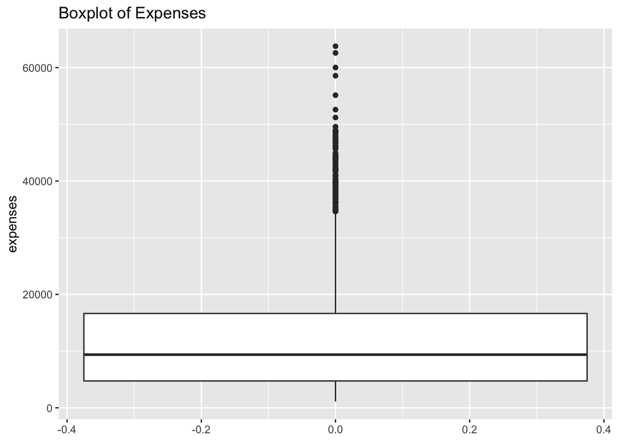

```r
# Load necessary library
library(ggplot2)

# Create a boxplot for expenses
ggplot(insurance, aes(y = expenses)) +
  geom_boxplot() +
  ggtitle("Boxplot of Expenses")
```

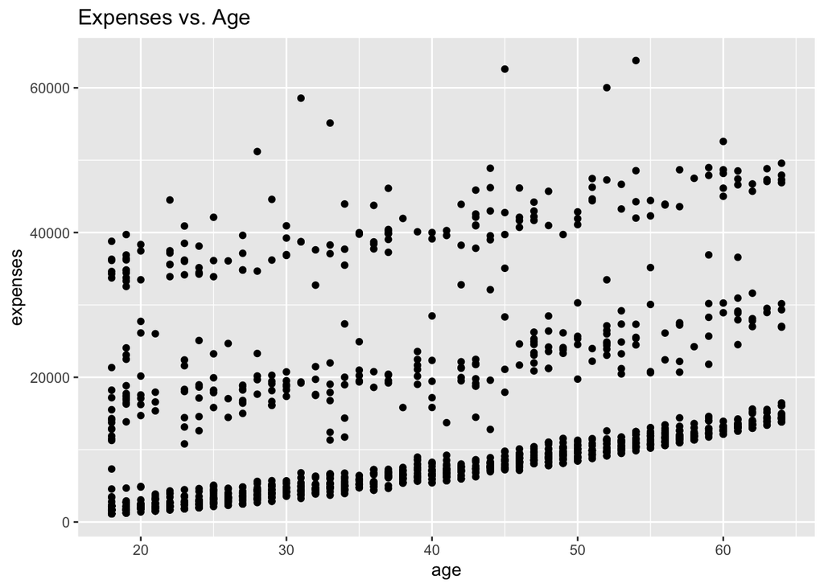

```r
# Scatter plot of expenses vs. age
ggplot(insurance, aes(x = age, y = expenses)) +
  geom_point() +
  ggtitle("Expenses vs. Age")
```

Z score to remove the outliers and standardize the mesaurig technique over the data

```r
# Calculate Z-scores for expenses
z_scores <- scale(insurance$expenses)

# Identify outliers
outliers <- which(abs(z_scores) > 3)

# Remove outliers
insurance_no_outliers <- insurance[-outliers, ]
```

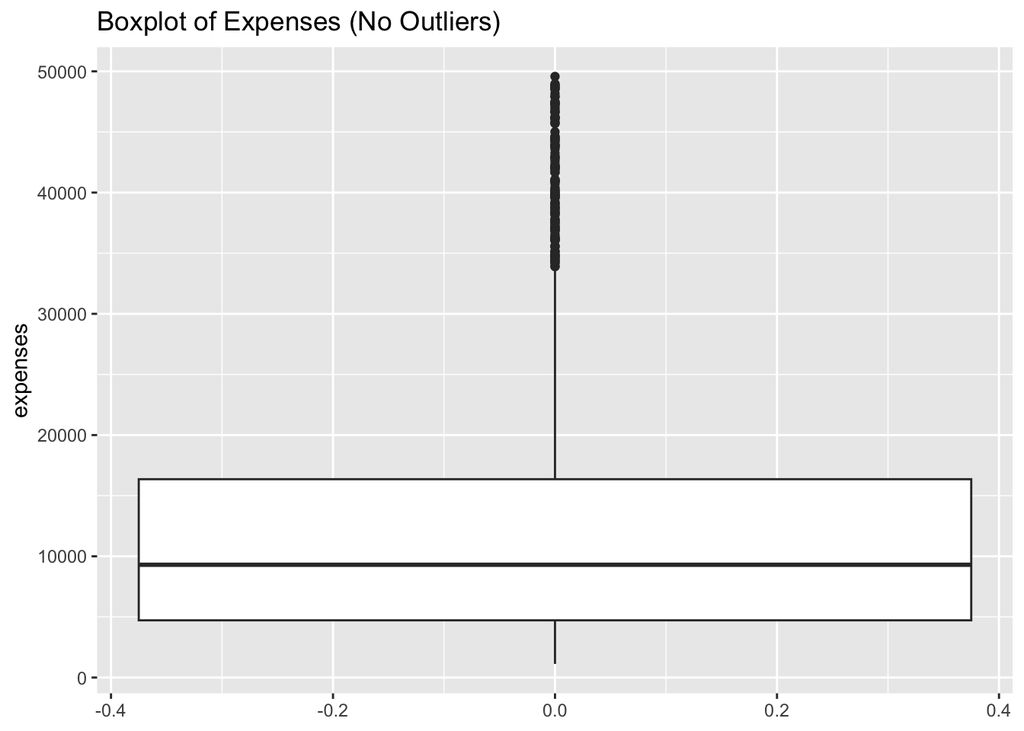

```r
# Boxplot after removing outliers
ggplot(insurance_no_outliers, aes(y = expenses)) +
  geom_boxplot() +
  ggtitle("Boxplot of Expenses (No Outliers)")
```

```r
set.seed(42)  # For reproducibility
train_index <- createDataPartition(insurance_no_outliers$expenses, p = 0.8, list = FALSE)
train_data <- insurance_no_outliers[train_index, ]
test_data <- insurance_no_outliers[-train_index, ]
```

```r
# Fit a linear regression model
lm_model <- lm(expenses ~ age + sex + bmi + children + smoker + region, data = train_data)

# Check the summary of the model
summary(lm_model)
```

```
##
## Call:
## lm(formula = expenses ~ age + sex + bmi + children + smoker +
##     region, data = train_data)
##
## Residuals:
##    Min     1Q Median     3Q    Max
## -11018  -2635  -1050   1139  24562
##
## Coefficients:
##                  Estimate Std. Error t value Pr(>|t|)
## (Intercept)     -11024.38    1052.80 -10.471  < 2e-16 ***
## age                257.05      12.62  20.360  < 2e-16 ***
## sexmale            -52.62     354.19  -0.149   0.8819
## bmi                303.96      30.59   9.937  < 2e-16 ***
## children           608.42     146.01   4.167 3.34e-05 ***
## smokeryes        23284.39     446.41  52.160  < 2e-16 ***
## regionnorthwest   -346.62     501.12  -0.692   0.4893
## regionsoutheast   -918.26     516.05  -1.779   0.0755 .
## regionsouthwest  -1269.36     514.19  -2.469   0.0137 *
## ---
## Signif. codes:  0 '***' 0.001 '**' 0.01 '*' 0.05 '.' 0.1 ' ' 1
##
## Residual standard error: 5753 on 1058 degrees of freedom
## Multiple R-squared:  0.7578, Adjusted R-squared:  0.756
## F-statistic: 413.9 on 8 and 1058 DF,  p-value: < 2.2e-16
```

```r
# Make predictions on the test set
predictions <- predict(lm_model, newdata = test_data)

# Evaluate the model
mse <- mean((test_data$expenses - predictions)^2)
rsq <- cor(test_data$expenses, predictions)^2

cat("Mean Squared Error on Test Set:", mse, "\n")
```

```
## Mean Squared Error on Test Set: 37991858
```

```r
cat("R-squared on Test Set:", rsq, "\n")
```

```
## R-squared on Test Set: 0.7323739
```

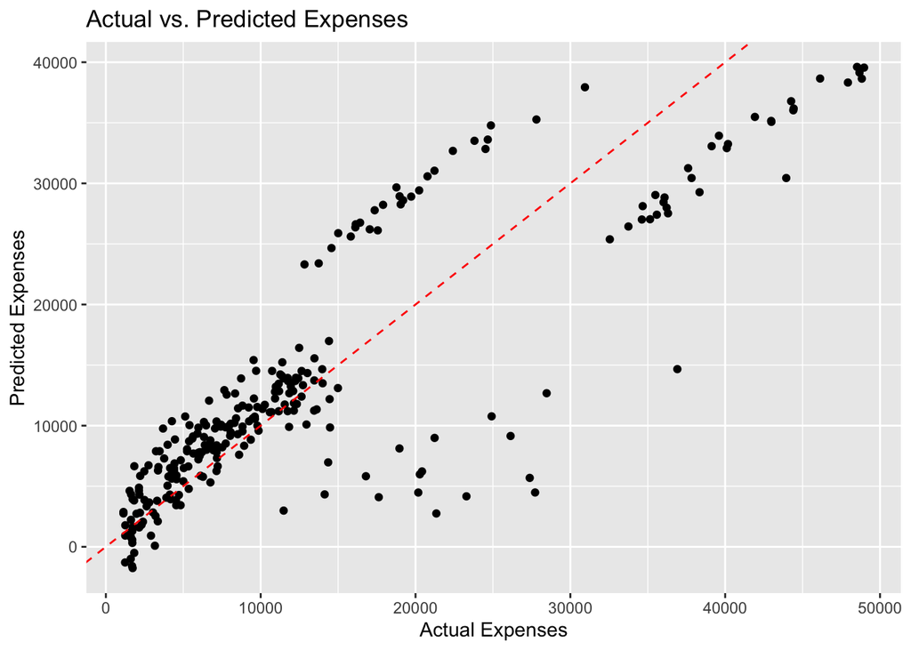

```r
# Create a data frame for plotting
results_df <- data.frame(Actual = test_data$expenses, Predicted = predictions)

# Scatter plot of Actual vs. Predicted
ggplot(results_df, aes(x = Actual, y = Predicted)) +
  geom_point() +
  geom_abline(slope = 1, intercept = 0, color = "red", linetype = "dashed") +
  ggtitle("Actual vs. Predicted Expenses") +
  xlab("Actual Expenses") +
  ylab("Predicted Expenses")
```

## create ploynomial and regularized regression to incerase the r square values

```r
# Create polynomial features
train_data <- train_data %>%
  mutate(age_squared = age^2,
         bmi_squared = bmi^2)

test_data <- test_data %>%
  mutate(age_squared = age^2,
         bmi_squared = bmi^2)
```

```r
# Fit polynomial regression model
poly_model <- lm(expenses ~ age + age_squared + bmi + bmi_squared + sex + children + smoker + region, data = train_data)

# Summary of the polynomial model
summary(poly_model)
```

```
##
## Call:
## lm(formula = expenses ~ age + age_squared + bmi + bmi_squared +
##     sex + children + smoker + region, data = train_data)
##
## Residuals:
##    Min     1Q Median     3Q    Max
## -10287  -2880  -1099   1170  24338
##
## Coefficients:
##                   Estimate Std. Error t value Pr(>|t|)
## (Intercept)     -10336.044   3741.450  -2.763 0.005834 **
## age                -71.767     86.062  -0.834 0.404525
## age_squared          4.131      1.072   3.853 0.000124 ***
## bmi                630.628    217.727   2.896 0.003852 **
## bmi_squared         -5.262      3.411  -1.543 0.123201
## sexmale            -69.414    351.682  -0.197 0.843570
## children           775.975    151.165   5.133 3.39e-07 ***
## smokeryes        23310.281    443.260  52.588  < 2e-16 ***
## regionnorthwest   -438.754    498.135  -0.881 0.378629
## regionsoutheast   -873.954    513.227  -1.703 0.088889 .
## regionsouthwest  -1288.221    510.605  -2.523 0.011784 *
## ---
## Signif. codes:  0 '***' 0.001 '**' 0.01 '*' 0.05 '.' 0.1 ' ' 1
##
## Residual standard error: 5712 on 1056 degrees of freedom
## Multiple R-squared:  0.7617, Adjusted R-squared:  0.7595
## F-statistic: 337.6 on 10 and 1056 DF,  p-value: < 2.2e-16
```

```r
# Make predictions
poly_predictions <- predict(poly_model, newdata = test_data)

# Calculate Mean Squared Error and R-squared
poly_mse <- mean((test_data$expenses - poly_predictions)^2)
poly_rsq <- cor(test_data$expenses, poly_predictions)^2

cat("Polynomial Regression Mean Squared Error:", poly_mse, "\n")
```

```
## Polynomial Regression Mean Squared Error: 36848208
```

```r
cat("Polynomial Regression R-squared:", poly_rsq, "\n")
```

```
## Polynomial Regression R-squared: 0.7403948
```

# regularized regression

```r
# Create model matrices
x_train <- model.matrix(expenses ~ age + bmi + children + sex + smoker + region, data = train_data)[, -1]  # Exclude intercept
y_train <- train_data$expenses

x_test <- model.matrix(expenses ~ age + bmi + children + sex + smoker + region, data = test_data)[, -1]
y_test <- test_data$expenses
```

```r
# Fit Lasso regression
lasso_model <- glmnet(x_train, y_train, alpha = 1)

# Use cross-validation to find the best lambda
set.seed(42)
cv_lasso <- cv.glmnet(x_train, y_train, alpha = 1)

# Best lambda
best_lambda_lasso <- cv_lasso$lambda.min
cat("Best Lambda for Lasso:", best_lambda_lasso, "\n")
```

```
## Best Lambda for Lasso: 72.58156
```

```r
# Make predictions with the best lambda
lasso_predictions <- predict(lasso_model, s = best_lambda_lasso, newx = x_test)

# Calculate Mean Squared Error and R-squared
lasso_mse <- mean((y_test - lasso_predictions)^2)
lasso_rsq <- cor(y_test, lasso_predictions)^2

cat("Lasso Regression Mean Squared Error:", lasso_mse, "\n")
```

```
## Lasso Regression Mean Squared Error: 37954442
```

```r
cat("Lasso Regression R-squared:", lasso_rsq, "\n")
```

```
## Lasso Regression R-squared: 0.732488
```

```r
# Fit Ridge regression
ridge_model <- glmnet(x_train, y_train, alpha = 0)

# Use cross-validation to find the best lambda
cv_ridge <- cv.glmnet(x_train, y_train, alpha = 0)

# Best lambda
best_lambda_ridge <- cv_ridge$lambda.min
cat("Best Lambda for Ridge:", best_lambda_ridge, "\n")
```

```
## Best Lambda for Ridge: 915.8754
```

```r
# Make predictions with the best lambda
ridge_predictions <- predict(ridge_model, s = best_lambda_ridge, newx = x_test)

# Calculate Mean Squared Error and R-squared
ridge_mse <- mean((y_test - ridge_predictions)^2)
ridge_rsq <- cor(y_test, ridge_predictions)^2

cat("Ridge Regression Mean Squared Error:", ridge_mse, "\n")
```

```
## Ridge Regression Mean Squared Error: 38416102
```

```r
cat("Ridge Regression R-squared:", ridge_rsq, "\n")
```

```
## Ridge Regression R-squared: 0.7318531
```

Part II

```r
# Load necessary library
library(lmtest)
# Perform Durbin-Watson test
dw_test <- dwtest(lm_model)
print(dw_test)
```

```
##
##  Durbin-Watson test
##
## data:  lm_model
## DW = 2.0583, p-value = 0.8306
## alternative hypothesis: true autocorrelation is greater than 0
```

DW = 2.0583: This value is very close to 2, indicating there is no significant autocorrelation in the residuals of your model.

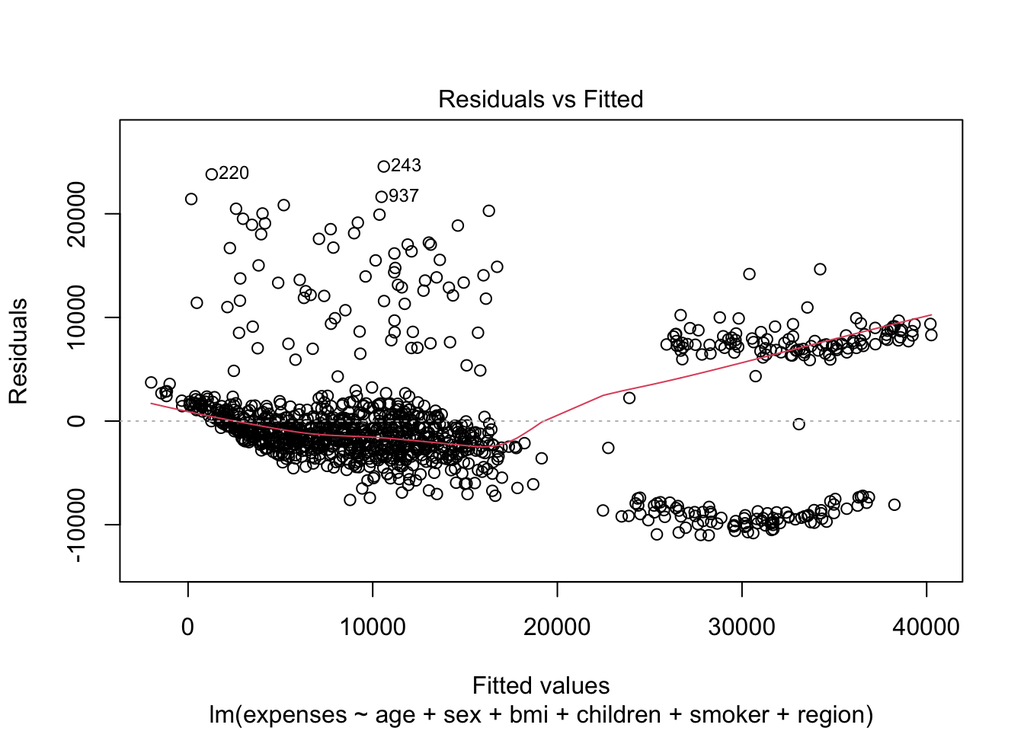

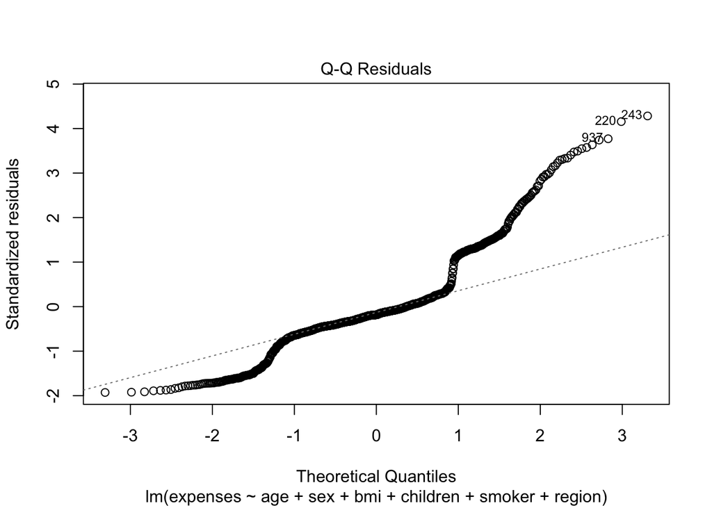

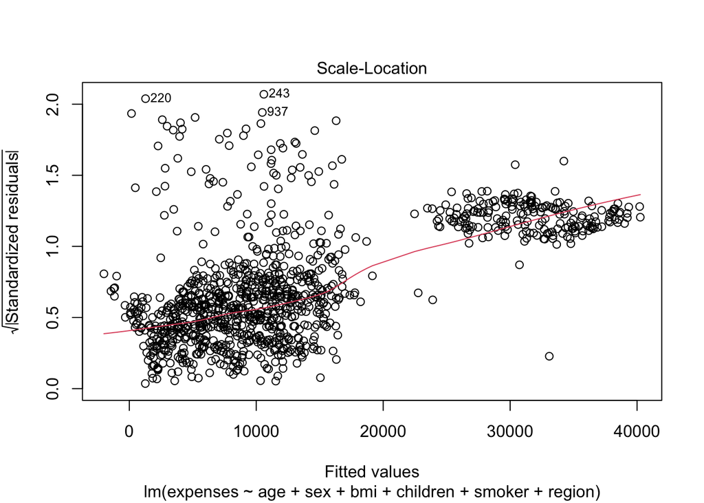

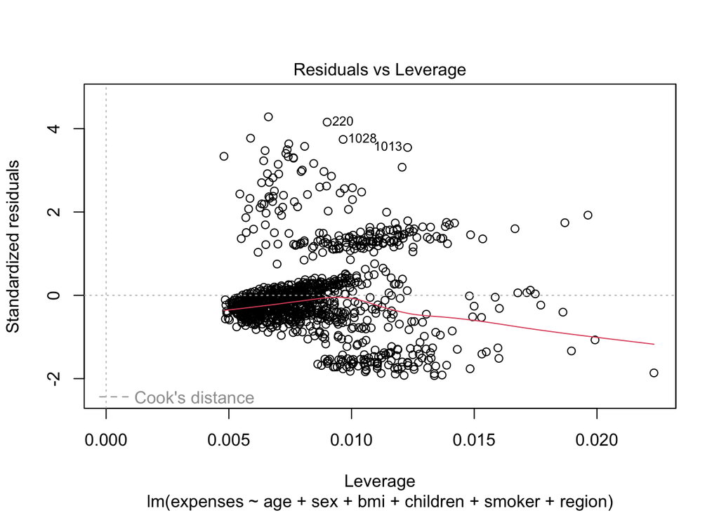

```r
# Plot residuals vs. fitted values
plot(lm_model)
```

```r
# Breusch-Pagan test
library(lmtest)
bptest(lm_model)
```

```
##
##  studentized Breusch-Pagan test
##
## data:  lm_model
## BP = 94.752, df = 8, p-value < 2.2e-16
```

```r
# Load necessary library
library(car)
# Calculate VIF
vif_values <- vif(lm_model)
print(vif_values)
```

```
##              GVIF Df GVIF^(1/(2*Df))
## age      1.018311  1        1.009114
## sex      1.011143  1        1.005556
## bmi      1.129345  1        1.062707
## children 1.004606  1        1.002300
## smoker   1.011989  1        1.005977
## region   1.116932  3        1.018602
```

All the VIF values are below 5, which is a common threshold indicating no serious multicollinearity issues.

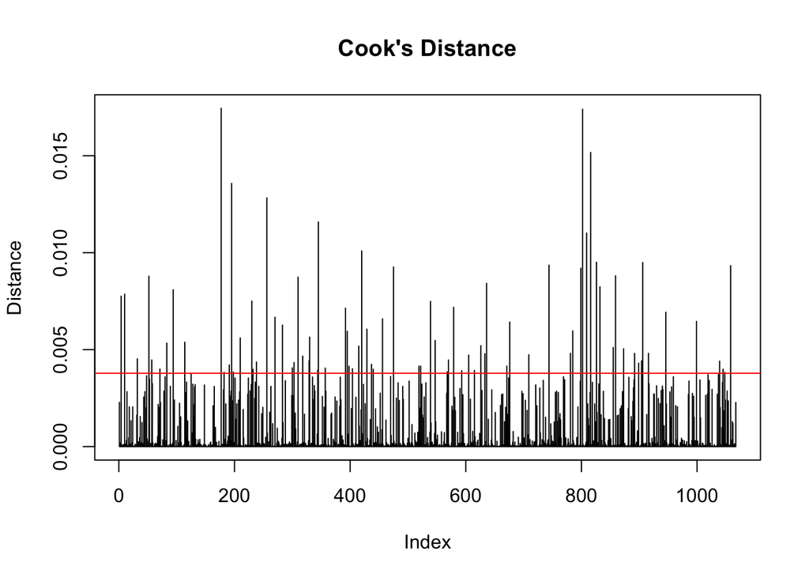

```r
# Calculate Cook's Distance
cooks_distance <- cooks.distance(lm_model)

# Plot Cook's Distance
plot(cooks_distance, type = "h", main = "Cook's Distance", ylab = "Distance")
abline(h = 4/(nrow(train_data) - length(coef(lm_model))), col = "red")  # Threshold line
```

The majority of the observations have a very low Cook’s Distance, indicating that they are not highly influential on the model. These potential influential points should be further investigated to understand their effect on the model’s coefficients, fit, and overall conclusions. Examining the reasons behind their high influence, evaluating the model’s sensitivity to their removal, and considering more robust regression techniques can help ensure the reliability and validity of the analysis. Addressing these influential observations is crucial to draw accurate and trustworthy conclusions from the regression model.

```r
# Fit the log-transformed model
log_model <- lm(log(expenses) ~ age + sex + bmi + children + smoker + region, data = train_data)

# Summary of the log-transformed model
summary(log_model)
```

```
##
## Call:
## lm(formula = log(expenses) ~ age + sex + bmi + children + smoker +
##     region, data = train_data)
##
## Residuals:
##      Min       1Q   Median       3Q      Max
## -1.03386 -0.19275 -0.04939  0.06409  2.15427
##
## Coefficients:
##                   Estimate Std. Error t value Pr(>|t|)
## (Intercept)      7.0290032  0.0792116  88.737  < 2e-16 ***
## age              0.0351233  0.0009499  36.976  < 2e-16 ***
## sexmale         -0.0855976  0.0266489  -3.212 0.001358 **
## bmi              0.0124035  0.0023014   5.390 8.71e-08 ***
## children         0.1075568  0.0109859   9.790  < 2e-16 ***
## smokeryes        1.5398384  0.0335873  45.846  < 2e-16 ***
## regionnorthwest -0.0573678  0.0377041  -1.522 0.128426
## regionsoutheast -0.1412375  0.0388270  -3.638 0.000288 ***
## regionsouthwest -0.1287256  0.0386869  -3.327 0.000907 ***
## ---
## Signif. codes:  0 '***' 0.001 '**' 0.01 '*' 0.05 '.' 0.1 ' ' 1
##
## Residual standard error: 0.4328 on 1058 degrees of freedom
## Multiple R-squared:  0.7749, Adjusted R-squared:  0.7731
## F-statistic: 455.1 on 8 and 1058 DF,  p-value: < 2.2e-16
```

```r
# Make predictions on the test set
test_predictions <- exp(predict(log_model, newdata = test_data))

# Calculate the mean squared error
mse <- mean((test_data$expenses - test_predictions)^2)
print(paste("Mean Squared Error on Test Set:", mse))
```

```
## [1] "Mean Squared Error on Test Set: 75515347.1996368"
```

```r
# Calculate the R-squared on the test set
r_squared <- 1 - sum((test_data$expenses - test_predictions)^2) / sum((test_data$expenses - mean(test_data$expenses))^2)
print(paste("R-squared on Test Set:", r_squared))
```

```
## [1] "R-squared on Test Set: 0.467716300732862"
```

To compare the performance of the multiple linear regression models with and without the log transformation applied to the response variable (expenses), we evaluate the model fit, the significance of predictors, and the residuals.

Model without Log Transformation: The model without the log transformation has an R-squared of 0.7617 and an Adjusted R-squared of 0.7595. The Residual Standard Error is 5712, and the F-statistic is 337.6, both of which are statistically significant. Important predictors such as `age_squared`, `bmi`, `children`, and `smokeryes` are found to be significant, but the residuals exhibit a broad range (Min: -10287, Max: 24338), indicating the presence of heteroscedasticity.